# Reproducible Research - Week 4 Peer Project

Vignesh C Iyer

7/12/2020

# Impact Analysis of Storm and Weather data

## Synopsis

Storms and other severe weather events can cause both public health and economic problems for communities and municipalities. Many severe events can result in fatalities, injuries, and property damage, and preventing such outcomes to the extent possible is a key concern.

This project involves exploring the U.S. National Oceanic and Atmospheric Administration’s (NOAA) storm database. This database tracks characteristics of major storms and weather events in the United States, including when and where they occur, as well as estimates of any fatalities, injuries, and property damage.

## Assignment

The basic goal of this assignment is to explore the NOAA Storm Database and answer some basic questions about severe weather events. You must use the database to answer the questions below and show the code for your entire analysis. Your analysis can consist of tables, figures, or other summaries. You may use any R package you want to support your analysis.

## Data Processing

The data for this assignment come in the form of a comma-separated-value file compressed via the bzip2 algorithm to reduce its size. You can download the file from the course web site:

[Storm Data](https://d396qusza40orc.cloudfront.net/repdata%2Fdata%2FStormData.csv.bz2)

There is also some documentation of the database available. Here you will find how some of the variables are constructed/defined.

- National Weather Service [Storm Data Documentation](https://d396qusza40orc.cloudfront.net/repdata%2Fpeer2_doc%2Fpd01016005curr.pdf)
- National Climatic Data Center Storm Events [FAQ](https://d396qusza40orc.cloudfront.net/repdata%2Fpeer2_doc%2FNCDC%20Storm%20Events-FAQ%20Page.pdf)

The events in the database start in the year 1950 and end in November 2011. In the earlier years of the database there are generally fewer events recorded, most likely due to a lack of good records. More recent years should be considered more complete.

### Data Pre-processing

The Storm Data is fetched, downloaded to the local system and then its contents are read based on the code given below

```r
# This section deals with the downloading the compressed file and
# extracting it contents.

stormData <- "https://d396qusza40orc.cloudfront.net/repdata%2Fdata%2FStormData.csv.bz2"

# The file is downloaded using the download.file function.
download.file(stormData, destfile = "../StormData.csv.bz2")

# reading data from the file
readStormData <- read.csv("../StormData.csv.bz2")

# Fetching column names of Storm Data using the colNames function
colnames(readStormData)
```

```
##  [1] "STATE__"    "BGN_DATE"   "BGN_TIME"   "TIME_ZONE"  "COUNTY"
##  [6] "COUNTYNAME" "STATE"      "EVTYPE"     "BGN_RANGE"  "BGN_AZI"
## [11] "BGN_LOCATI" "END_DATE"   "END_TIME"   "COUNTY_END" "COUNTYENDN"
## [16] "END_RANGE"  "END_AZI"    "END_LOCATI" "LENGTH"     "WIDTH"
## [21] "F"          "MAG"        "FATALITIES" "INJURIES"   "PROPDMG"
## [26] "PROPDMGEXP" "CROPDMG"    "CROPDMGEXP" "WFO"        "STATEOFFIC"
## [31] "ZONENAMES"  "LATITUDE"   "LONGITUDE"  "LATITUDE_E" "LONGITUDE_"
## [36] "REMARKS"    "REFNUM"
```

```r
str(readStormData)
```

```
## 'data.frame':    902297 obs. of  37 variables:
##  $ STATE__   : num  1 1 1 1 1 1 1 1 1 1 ...
##  $ BGN_DATE  : chr  "4/18/1950 0:00:00" "4/18/1950 0:00:00" "2/20/1951 0:00:00" "6/8/1951 0:00:00" ...
##  $ BGN_TIME  : chr  "0130" "0145" "1600" "0900" ...
##  $ TIME_ZONE : chr  "CST" "CST" "CST" "CST" ...
##  $ COUNTY    : num  97 3 57 89 43 77 9 123 125 57 ...
##  $ COUNTYNAME: chr  "MOBILE" "BALDWIN" "FAYETTE" "MADISON" ...
##  $ STATE     : chr  "AL" "AL" "AL" "AL" ...
##  $ EVTYPE    : chr  "TORNADO" "TORNADO" "TORNADO" "TORNADO" ...
##  $ BGN_RANGE : num  0 0 0 0 0 0 0 0 0 0 ...
##  $ BGN_AZI   : chr  "" "" "" "" ...
##  $ BGN_LOCATI: chr  "" "" "" "" ...
##  $ END_DATE  : chr  "" "" "" "" ...
##  $ END_TIME  : chr  "" "" "" "" ...
##  $ COUNTY_END: num  0 0 0 0 0 0 0 0 0 0 ...
```

[output cut: 23 more lines]

```r
# Fetching first few rows of Storm Data
head(readStormData)
```

```
##   STATE__           BGN_DATE BGN_TIME TIME_ZONE COUNTY COUNTYNAME STATE  EVTYPE
## 1       1  4/18/1950 0:00:00     0130       CST     97     MOBILE    AL TORNADO
## 2       1  4/18/1950 0:00:00     0145       CST      3    BALDWIN    AL TORNADO
## 3       1  2/20/1951 0:00:00     1600       CST     57    FAYETTE    AL TORNADO
## 4       1   6/8/1951 0:00:00     0900       CST     89    MADISON    AL TORNADO
## 5       1 11/15/1951 0:00:00     1500       CST     43    CULLMAN    AL TORNADO
## 6       1 11/15/1951 0:00:00     2000       CST     77 LAUDERDALE    AL TORNADO
##   BGN_RANGE BGN_AZI BGN_LOCATI END_DATE END_TIME COUNTY_END COUNTYENDN
## 1         0                                               0         NA
## 2         0                                               0         NA
## 3         0                                               0         NA
## 4         0                                               0         NA
## 5         0                                               0         NA
## 6         0                                               0         NA
##   END_RANGE END_AZI END_LOCATI LENGTH WIDTH F MAG FATALITIES INJURIES PROPDMG
```

[output cut: 20 more lines]

```r
# fetching the unique event type in the Storm Data
head(unique(readStormData$EVTYPE))
```

```
## [1] "TORNADO"               "TSTM WIND"             "HAIL"
## [4] "FREEZING RAIN"         "SNOW"                  "ICE STORM/FLASH FLOOD"
```

We notice that the Date format is that of a Character from the below code

```r
class(readStormData$BGN_DATE)
```

```
## [1] "character"
```

```r
readStormData$BGN_DATE <- as.Date(readStormData$BGN_DATE, format = "%m%d%Y %H:%m:%s")
class(readStormData$BGN_DATE)
```

```
## [1] "Date"
```

Getting the events type as a Data Frame

```r
# subsetting the Storm Data
readStormData <- subset(readStormData,
                        select = c(EVTYPE, FATALITIES,
                          INJURIES, PROPDMG, PROPDMGEXP, CROPDMG,
                          CROPDMGEXP))
```

#### 1. Across the United States, which types of events (as indicated in the EVTYPE variable) are most harmful with respect to population health?

Since we have already subset the original data based on the EVTYPE, FATALITIES, INJURIES, PROPDMG, PROPDMGEXP, CROPDMG and CROPDMGEXP we now need to process the data further in such a way that for each “EVTYPE” we need to find the FATALTIES and INJURIES.

Doing the above process would give us an insight as to which event type caused maximum fatalities and injuries.

```r
library(dplyr)
# Aggregating and arranging the Fatalities and Injuries

stormDataFatalities <- arrange(
  aggregate(FATALITIES ~ EVTYPE, data = readStormData, sum),
  desc(FATALITIES), EVTYPE)[1:10,]

# Aggregated data of the Storm Fatalities based on the event type
stormDataFatalities
```

```
##            EVTYPE FATALITIES
## 1         TORNADO       5633
## 2  EXCESSIVE HEAT       1903
## 3     FLASH FLOOD        978
## 4            HEAT        937
## 5       LIGHTNING        816
## 6       TSTM WIND        504
## 7           FLOOD        470
## 8     RIP CURRENT        368
## 9       HIGH WIND        248
## 10      AVALANCHE        224
```

```r
stormDataInjuries <- arrange(
  aggregate(INJURIES ~ EVTYPE, data = readStormData, sum),
  desc(INJURIES), EVTYPE)[1:10,]

# Aggregated data of the Storm Injuries based on the event type
stormDataInjuries
```

```
##               EVTYPE INJURIES
## 1            TORNADO    91346
## 2          TSTM WIND     6957
## 3              FLOOD     6789
## 4     EXCESSIVE HEAT     6525
## 5          LIGHTNING     5230
## 6               HEAT     2100
## 7          ICE STORM     1975
## 8        FLASH FLOOD     1777
## 9  THUNDERSTORM WIND     1488
## 10              HAIL     1361
```

From both the “stormDataFatalities” and “stormDataInjuries” we can see that event type “TORNADO” has registered the highest number of Fatalities and Injuries, now let is plot the same on the graph.

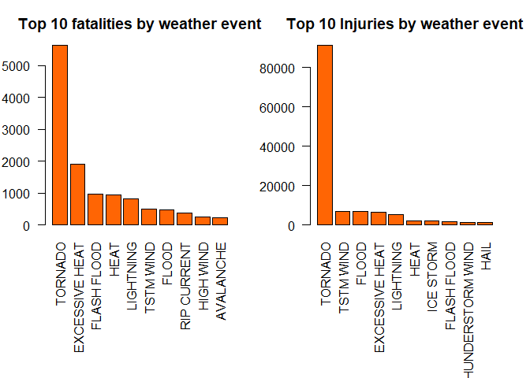

```r
library(lattice)
# plotting the graphs for the Fatalities and Injuries

par(mfrow=c(1,2),mar=c(10,3,3,2))

# Fatalities by event type

barplot(stormDataFatalities$FATALITIES,
        names.arg=stormDataFatalities$EVTYPE,
        las=2,
        col="#FF6504",
        ylab="Fatalities",
        main="Top 10 fatalities by weather event")

# Injuries by event type
barplot(stormDataInjuries$INJURIES,
        names.arg=stormDataInjuries$EVTYPE,
        las=2,
        col="#FF6504",
        ylab="Injuries",
        main="Top 10 Injuries by weather event")
```

#### 2. Across the United States, which types of events have the greatest economic consequences?

The greatest economic consequences can be measured by the columns PROPDMG, PROPDMGEXP, CROPDMG, CROPDMGEXP.

The columns names denote the following

- PROPDMG –> Property Damage
- CROPGMG –> Crop Damage
- PROPDMGEXP –> Property Damage Exponent
- CROPDMGEXP –> Crop Damage Exponent

We need to first associate the Damage caused to the Event type.

To do that we need to convert the notations “K”,“M”,"“,”B“,”m“,”+“,”0“,”5“,”6“,”?“,”4“,”2“,”3“,”h“,”7“,”H“,”-" “1”,“8” to their corresponding powers of 10 or exponential values.

For example:

and so on.. We do that by the following operation

```r
unique(readStormData$PROPDMGEXP)
```

```
##  [1] "K" "M" ""  "B" "m" "+" "0" "5" "6" "?" "4" "2" "3" "h" "7" "H" "-" "1" "8"
```

```r
# convert the notations "K","M","","B","m","+","0","5","6","?","4","2","3","h","7",
# "H","-" "1","8" to their corresponding powers of 10 or exponential values.

readStormData$PROPEXP[readStormData$PROPDMGEXP == "K"] <- 1000
readStormData$PROPEXP[readStormData$PROPDMGEXP == "M"] <- 1000000
readStormData$PROPEXP[readStormData$PROPDMGEXP == ""] <- 1
readStormData$PROPEXP[readStormData$PROPDMGEXP == "B"] <- 1000000000
readStormData$PROPEXP[readStormData$PROPDMGEXP == "m"] <- 1000000
readStormData$PROPEXP[readStormData$PROPDMGEXP == "0"] <- 1
readStormData$PROPEXP[readStormData$PROPDMGEXP == "5"] <- 100000
readStormData$PROPEXP[readStormData$PROPDMGEXP == "6"] <- 1000000
readStormData$PROPEXP[readStormData$PROPDMGEXP == "4"] <- 10000
readStormData$PROPEXP[readStormData$PROPDMGEXP == "2"] <- 100
readStormData$PROPEXP[readStormData$PROPDMGEXP == "3"] <- 1000
readStormData$PROPEXP[readStormData$PROPDMGEXP == "h"] <- 100
readStormData$PROPEXP[readStormData$PROPDMGEXP == "7"] <- 10000000
readStormData$PROPEXP[readStormData$PROPDMGEXP == "H"] <- 100
readStormData$PROPEXP[readStormData$PROPDMGEXP == "1"] <- 10
readStormData$PROPEXP[readStormData$PROPDMGEXP == "8"] <- 100000000
# Assigning '0' to invalid exponent data
readStormData$PROPEXP[readStormData$PROPDMGEXP == "+"] <- 0
readStormData$PROPEXP[readStormData$PROPDMGEXP == "-"] <- 0
readStormData$PROPEXP[readStormData$PROPDMGEXP == "?"] <- 0

class(readStormData$PROPEXP)
```

```
## [1] "numeric"
```

```r
# Calculating the property damage value

stormPropertyDamage <- readStormData$PROPDMG * readStormData$PROPEXP
```

After having converted the notations for property damage we now need to do the same for the crop damage which will be achieved by the following code

```r
unique(readStormData$CROPDMGEXP)
```

```
## [1] ""  "M" "K" "m" "B" "?" "0" "k" "2"
```

```r
# Assigning values for the crop exponent data
readStormData$CROPEXP[readStormData$CROPDMGEXP == "M"] <- 1000000
readStormData$CROPEXP[readStormData$CROPDMGEXP == "K"] <- 1000
readStormData$CROPEXP[readStormData$CROPDMGEXP == "m"] <- 1000000
readStormData$CROPEXP[readStormData$CROPDMGEXP == "B"] <- 1000000000
readStormData$CROPEXP[readStormData$CROPDMGEXP == "0"] <- 1
readStormData$CROPEXP[readStormData$CROPDMGEXP == "k"] <- 1000
readStormData$CROPEXP[readStormData$CROPDMGEXP == "2"] <- 100
readStormData$CROPEXP[readStormData$CROPDMGEXP == ""] <- 1
# Assigning '0' to invalid exponent data
readStormData$CROPEXP[readStormData$CROPDMGEXP == "?"] <- 0

stormCropDamage <- readStormData$CROPDMG * readStormData$CROPEXP
```

Printing out the Column names

```r
colnames(readStormData)
```

```
## [1] "EVTYPE"     "FATALITIES" "INJURIES"   "PROPDMG"    "PROPDMGEXP"
## [6] "CROPDMG"    "CROPDMGEXP" "PROPEXP"    "CROPEXP"
```

```r
# Calculating the total damage
readStormData$stormTotalDamage <- stormPropertyDamage + stormCropDamage

colnames(readStormData)
```

```
##  [1] "EVTYPE"           "FATALITIES"       "INJURIES"         "PROPDMG"
##  [5] "PROPDMGEXP"       "CROPDMG"          "CROPDMGEXP"       "PROPEXP"
##  [9] "CROPEXP"          "stormTotalDamage"
```

```r
# Finding the top 10 events based on which the maximum economic destruction has occurred

propertydamage <- arrange(
  aggregate(
    stormPropertyDamage ~ EVTYPE,
    data=readStormData, sum),
  desc(stormPropertyDamage),EVTYPE)[1:10,]

propertydamage
```

```
##               EVTYPE stormPropertyDamage
## 1              FLOOD        144657709807
## 2  HURRICANE/TYPHOON         69305840000
## 3            TORNADO         56947380617
## 4        STORM SURGE         43323536000
## 5        FLASH FLOOD         16822673979
## 6               HAIL         15735267513
## 7          HURRICANE         11868319010
## 8     TROPICAL STORM          7703890550
## 9       WINTER STORM          6688497251
## 10         HIGH WIND          5270046260
```

```r
cropdamage <- arrange(
  aggregate(
    stormCropDamage ~ EVTYPE,
    data=readStormData, sum),
  desc(stormCropDamage),EVTYPE)[1:10,]

cropdamage
```

```
##               EVTYPE stormCropDamage
## 1            DROUGHT     13972566000
## 2              FLOOD      5661968450
## 3        RIVER FLOOD      5029459000
## 4          ICE STORM      5022113500
## 5               HAIL      3025954473
## 6          HURRICANE      2741910000
## 7  HURRICANE/TYPHOON      2607872800
## 8        FLASH FLOOD      1421317100
## 9       EXTREME COLD      1292973000
## 10      FROST/FREEZE      1094086000
```

```r
totaldamage <- arrange(
  aggregate(
    stormTotalDamage ~ EVTYPE,
    data=readStormData, sum),
  desc(stormTotalDamage),EVTYPE)[1:10,]

totaldamage
```

```
##               EVTYPE stormTotalDamage
## 1              FLOOD     150319678257
## 2  HURRICANE/TYPHOON      71913712800
## 3            TORNADO      57362333887
## 4        STORM SURGE      43323541000
## 5               HAIL      18761221986
## 6        FLASH FLOOD      18243991079
## 7            DROUGHT      15018672000
## 8          HURRICANE      14610229010
## 9        RIVER FLOOD      10148404500
## 10         ICE STORM       8967041360
```

There is a certain level of damage and destruction that occurs during any sort of natural calamity which amounts to certain economical losses.

Plotting the graphs for Property, Crop and total damage

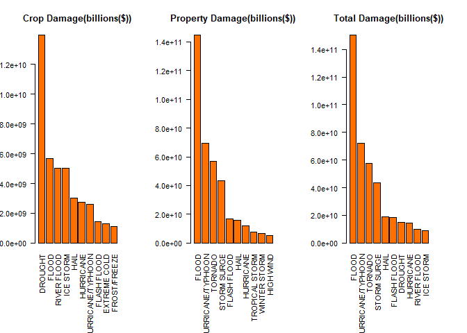

```r
library(lattice)
library(dplyr)
par(mfrow=c(1,3),mar=c(10,4,4,4))

# Plotting CROP Damage in billions($) based on the top ten event types
barplot(cropdamage$stormCropDamage,
        names.arg = cropdamage$EVTYPE,
        las = 2,
        col="#FF7002",
        main="Crop Damage(billions($))")

# Plotting PROPERTY Damage in billions($) based on the top ten event types
barplot(propertydamage$stormPropertyDamage,
        names.arg = propertydamage$EVTYPE,
        las =2,
        col = "#FF7002",
        main="Property Damage(billions($))")

# Plotting TOTAL damage in billions($) based on the top ten event types
barplot(totaldamage$stormTotalDamage,
        names.arg = totaldamage$EVTYPE,
        las = 2,
        col = "#FF7002",
        main = "Total Damage(billions($))")
```